# Machine Learning in clinical development

The what?, the why?, and (a bit of) the how?

Eliana Garcia Cossio, Antigoni Elefsinioti, Sandra Gonzalez Maldonado

2024-11-11

**Demo: Random Survival Forests on simulated data**

This demo aims at providing an overview of applying Random Survival Forests on simulated data. We are splitting the demo in the following steps

1. Data generation
2. Data training-testing split
3. Data pre-processing
4. Setup model
5. Hyperparameter tuning
6. Final model training and performance evaluation
7. Explainable AI
- VIMP (Variable Importance)
- Partial dependency plots (PDPs)

# Data generation

We simulate data and also right-censored survival outcome, using a proportional hazard model with time-constant baseline hazard, such as

$Surv(time,status) \sim 0.3*bm01+0.6*bm02+0.4*bm03+0.1*bm04-trt-1.5*trt*bm01$ $-1.5*trt*bm05-1.5*trt*bm06 + noise(bm07...bm20)$

Where:

- Main effects $0.3*bm01+0.6*bm02+0.4*bm03+0.1*bm04-trt$
- Interaction with treatment $-1.5*trt*bm01-1.5*trt*bm05-1.5*trt*bm06$

This function `biospear::simdata` simulates a data set with survival outcome with given active biomarkers (prognostic and/or interacting with the treatment).

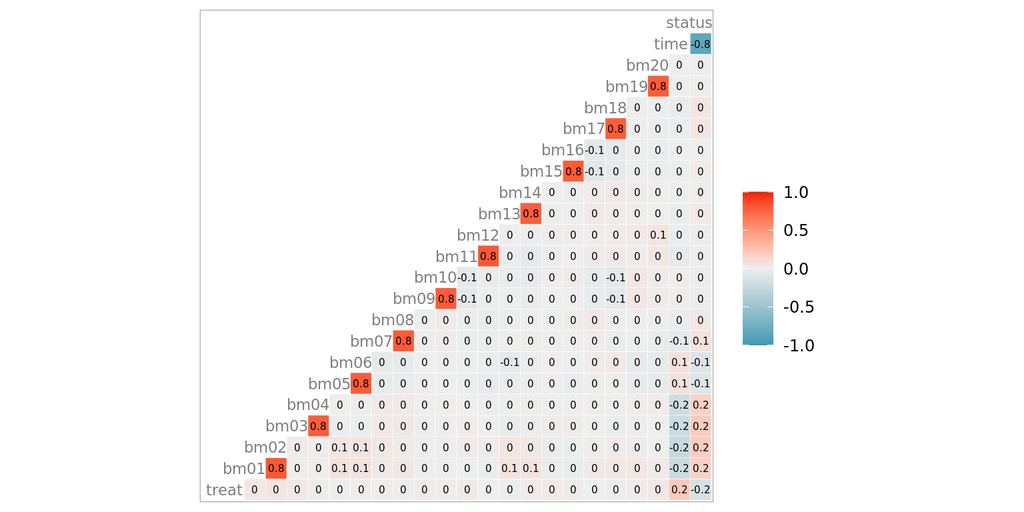

```r
library(biospear)
library(tidyverse)
library(GGally)

#The simdata function generates p Gaussian unit-variance (σ = 1) biomarkers including autoregressive correlation (σ_ij = b.corr^|i-j|) within b.corr.by-biomarker blocks.
#The number of active biomarkers and their effect sizes (in log-scale) can be specified using q.main and beta.main for the true prognostic biomarkers and using q.inter
#and beta.inter for the true treatment-effect modifiers. A total of n patients is generated and randomly assigned to the experimental (coded as +0.5, with probability prob.tt)
#and control treatment (coded as -0.5). The treatment effect is specified using alpha.tt (in log-scale). Survival times are generated using a Weibull with shape wei.shape
#(i.e. 1 = exponential distribution) and patient-specific scale depending on the baseline median survival time m0 and the biomarkers values of the patient.
#Censor status is generated by considering independant censoring from a U(fu, fu + recr) distribution, reflecting a trial with recr years of accrual and fu years of follow-up.
#Another data set with the same characteristics as the one generated by simdata can be obtained by using the simdataV function.

n = 1500
p = 20

# Set a seed for reproducibility
set.seed(567)

# specify which biomarkers are prognostic
Xprog <- c("bm01","bm02","bm03","bm04")
# specify which biomarkers are predictive
Xpred <- c("bm01","bm05","bm06")

Xprogpred <- dplyr::intersect(Xpred,Xprog)
XsolelyProg <- dplyr::setdiff(Xprog, Xpred)    # set differentiation
q = length(Xpred)

dataBM <- biospear::simdata(
  # the sample size
  n = n,
  # the number of biomarkers
  p = p,
  # the number of true prognostic biomarkers.
  q.main = 4 ,
  # the number of true biomarkers interacting with the treatement.
  q.inter = 3,
  # the treatment assignment probability.
  prob.tt = 0.5,
  # baseline median survival time.
  m0 = 5,
  # the effect of the treatment (in log-scale)~ 0.37
  alpha.tt = -1,
  # the effect of the prognostic biomarkers (in log-scale)
  beta.main = c(0.3, 0.6, 0.4, 0.1),
  # the effect of the biomarkers interacting with the treatment (in log-scale)
  beta.inter = rep(-1.5, 3),
  # the correlation between biomarker blocks
  b.corr = 0.8,
  # the size of the blocks of correlated biomarkers
  b.corr.by = 2,
  # the shape parameter of the Weibull distribution
  wei.shape = 1,
  # the recruitment period duration
  recr = 1,
  # the follow-up period duration
  fu = 10,
  # the scale multiplicative factor for times (i.e. 1 = times in years)
  timefactor = 1,
  # the list of the prognostic biomarkers (not mandatory).
  active.main = Xprog,
  # the list of the biomarkers interacting with the treatment (not mandatory).
  active.inter = Xpred
)

# Visualizing the correlation structure
ggcorr(dataBM ,
       layout.exp = 1,
       label = TRUE,
       label_size = 2,
       hjust = 0.75,
       size = 3,
       color = "grey50")
```

We will add some transformations to the data, to make it closer to a real scenario:

- Our treatment variable will be dichotomize
- Introducing missing values to the data
- Transforming other numeric into categorical variables
- Adding an id column

```r
dataBM <- dataBM %>%
  rename(.status = status,  # renaming status, time
         .time = time) %>%
  # before: A total of n patients is generated and randomly assigned to the experimental
  #(coded as +0.5, with probability prob.tt) and control treatment (coded as -0.5
  dplyr::mutate(.trt = ifelse(treat == "-0.5",
                              "control",
                              "active"))  %>% # preparing the data in suited form. -0.5 was
  select(-treat)


# Introducing missing values in the data set

# Set a seed for reproducibility
set.seed(123)

# Create a copy of the dataset
dataBM_with_na <- dataBM

# Define the proportion of missing values to introduce
proportion_missing <- 0.005  # 0.5% missing values

# Calculate the number of missing values to introduce
n_missing <- round(proportion_missing * nrow(dataBM_with_na) * ncol(dataBM_with_na))

# Randomly select indices for missing values
missing_indices <- sample(1:(nrow(dataBM_with_na) * ncol(dataBM_with_na)), n_missing)

# Introduce NA values systematically
for (index in missing_indices) {
  row <- (index - 1) %/% ncol(dataBM_with_na) + 1
  col <- (index - 1) %% ncol(dataBM_with_na) + 1
  dataBM_with_na[row, col] <- NA
}

# for our demo we will assume that we won't do any imputation on the outcomes and treatment information
# therefore, we need to remove missing values on these variables

dataBM_with_na <- dataBM_with_na %>%
  filter(!is.na(.trt), !is.na(.time), !is.na(.status))


# creating also other categorical variables bm07 and bm09

data <- dataBM_with_na %>%
  dplyr::mutate(bm07 = ifelse(bm07 < -1,          # # below -1 y otherwise N
                              "Y",
                              "N"),
                bm09 = ifelse(bm09 > 1,          # # above 1 y otherwise N
                              "Y",
                              "N")) %>%
  mutate(bm07 = as.factor(bm07),
         bm09 = as.factor(bm09),
         .trt = as.factor(.trt))

# Adding id column

data <- tibble::rownames_to_column(data, ".id")

data <- data%>%
  mutate(.id = paste0("id_", .id))
```

```r
#load utility packages
library(kableExtra)
library(here)
library(tictoc)
library(stringr)
library(qs)
library(skimr)
```

## Exploring the data

```r
data%>% skimr::skim()
```

Data summary

| Name | Piped data |
| --- | --- |
| Number of rows | 1483 |
| Number of columns | 24 |
| _______________________ |  |
| Column type frequency: |  |
| character | 1 |
| factor | 3 |
| numeric | 20 |
| ________________________ |  |
| Group variables | None |

**Variable type: character**

| skim_variable | n_missing | complete_rate | min | max | empty | n_unique | whitespace |
| --- | --- | --- | --- | --- | --- | --- | --- |
| .id | 0 | 1 | 4 | 7 | 0 | 1483 | 0 |

**Variable type: factor**

| skim_variable | n_missing | complete_rate | ordered | n_unique | top_counts |
| --- | --- | --- | --- | --- | --- |
| bm07 | 9 | 0.99 | FALSE | 2 | N: 1214, Y: 260 |
| bm09 | 5 | 1.00 | FALSE | 2 | N: 1254, Y: 224 |
| .trt | 0 | 1.00 | FALSE | 2 | act: 766, con: 717 |

**Variable type: numeric**

| skim_variable | n_missing | complete_rate | mean | sd | p0 | p25 | p50 | p75 | p100 | hist |
| --- | --- | --- | --- | --- | --- | --- | --- | --- | --- | --- |
| bm01 | 5 | 1.00 | 0.00 | 0.97 | -3.36 | -0.62 | -0.03 | 0.66 | 3.30 | ▁▃▇▃▁ |
| bm02 | 7 | 1.00 | -0.01 | 0.99 | -3.09 | -0.67 | -0.01 | 0.65 | 3.41 | ▁▅▇▃▁ |
| bm03 | 6 | 1.00 | 0.02 | 0.99 | -3.20 | -0.67 | 0.00 | 0.71 | 3.30 | ▁▅▇▃▁ |
| bm04 | 12 | 0.99 | 0.04 | 0.98 | -3.26 | -0.65 | 0.02 | 0.69 | 3.17 | ▁▃▇▅▁ |
| bm05 | 7 | 1.00 | 0.02 | 1.01 | -3.12 | -0.67 | -0.01 | 0.71 | 3.27 | ▁▅▇▃▁ |
| bm06 | 9 | 0.99 | 0.01 | 1.00 | -3.09 | -0.63 | 0.02 | 0.69 | 3.53 | ▁▅▇▃▁ |
| bm08 | 10 | 0.99 | -0.07 | 1.03 | -3.12 | -0.79 | -0.07 | 0.65 | 3.50 | ▁▅▇▃▁ |
| bm10 | 7 | 1.00 | -0.02 | 0.99 | -3.10 | -0.68 | -0.01 | 0.63 | 3.50 | ▁▅▇▃▁ |
| bm11 | 4 | 1.00 | -0.02 | 1.01 | -3.21 | -0.69 | -0.04 | 0.66 | 3.98 | ▁▆▇▂▁ |
| bm12 | 8 | 0.99 | -0.03 | 1.03 | -2.80 | -0.70 | -0.03 | 0.67 | 3.61 | ▂▆▇▂▁ |
| bm13 | 5 | 1.00 | 0.01 | 0.96 | -3.25 | -0.64 | -0.01 | 0.66 | 3.02 | ▁▃▇▅▁ |
| bm14 | 5 | 1.00 | -0.01 | 0.99 | -3.55 | -0.71 | -0.01 | 0.65 | 3.01 | ▁▃▇▅▁ |
| bm15 | 10 | 0.99 | 0.03 | 0.98 | -3.17 | -0.61 | 0.03 | 0.68 | 3.15 | ▁▃▇▅▁ |
| bm16 | 8 | 0.99 | 0.03 | 1.01 | -2.96 | -0.60 | 0.02 | 0.74 | 3.62 | ▁▅▇▂▁ |
| bm17 | 14 | 0.99 | 0.02 | 0.96 | -2.77 | -0.63 | 0.03 | 0.68 | 2.95 | ▁▅▇▃▁ |
| bm18 | 7 | 1.00 | 0.00 | 0.97 | -3.08 | -0.67 | -0.01 | 0.68 | 3.39 | ▁▅▇▃▁ |
| bm19 | 9 | 0.99 | -0.04 | 1.04 | -3.20 | -0.74 | -0.03 | 0.65 | 3.42 | ▁▅▇▃▁ |
| bm20 | 7 | 1.00 | -0.04 | 1.03 | -3.36 | -0.74 | -0.04 | 0.67 | 3.37 | ▁▃▇▃▁ |
| .time | 0 | 1.00 | 5.60 | 4.36 | 0.00 | 0.99 | 5.21 | 10.30 | 11.00 | ▇▂▂▁▇ |
| .status | 0 | 1.00 | 0.64 | 0.48 | 0.00 | 0.00 | 1.00 | 1.00 | 1.00 | ▅▁▁▁▇ |

# Data training-testing split

We can start by loading the tidymodels metapackage and splitting our data into training and testing sets . We will use 75% for training the model and 25% for testing.

```r
library(tidymodels)

set.seed(123)
#create a single binary split of the data into a training set and testing set,
#doing a stratified approach based on the outcome .status

#prop = The proportion of data to be retained for modeling/analysis. default: prop = 3/4
data_split <- rsample::initial_split(data, strata = .status)

#extract  the resulting data
data_train <- rsample::training(data_split)
data_test <- rsample::testing(data_split)
```

# Data pre-processing

We pre-process the training data and apply exactly the same step to the test data:

- Imputing the missing data using k-nearest neighbors (with the exception of .trt)
- NA-omit of predictors if after imputation we still have missing values
- Near zero variance features
- Correlation filter with r= 0.75

Other steps include: Normalization of data (given our data generation process we do not require this step) or dummy encoding (for Random Forest this is not necessary).

Below we can see how the data has been transformed.

```r
> #textrecipes contain extra steps for the recipes package for preprocessing text data.
> library(textrecipes)
>
> # make a recipe using the training data ####
> tte_recipe <-
+   # set the formula
+   recipes::recipe(formula = .time + .status ~ ., data = data_train) %>%
+   # define id role
+   recipes::update_role(.id, new_role = "id") %>%
+   # define outcomes role
+   recipes::update_role(c(.time, .status), new_role = "outcome") %>%
+   # KNN imputation
+   recipes::step_impute_knn(recipes::all_predictors(), -.trt) %>%
+   # na removal
+   recipes::step_naomit(recipes::all_predictors()) %>%
+   # near-zero variance filter
+   recipes::step_nzv(recipes::all_predictors(),
+                     freq_cut = 95 / 5,
+                     unique_cut = 10) %>%
+   # correlation filter
+   recipes::step_corr(recipes::all_numeric_predictors(), threshold = 0.75)#%>%
>
>
> #prepare new data####
> prep_tte_recipe <- tte_recipe %>%
+   recipes::prep()
>
> print(prep_tte_recipe)
```

```
## ── Recipe ──────────────────────────────────────────────────────────────────────
```

```
## ── Inputs
```

```
## Number of variables by role
```

```
## outcome:    2
## predictor: 21
## id:         1
```

```
## ── Training information
```

```
## Training data contained 1111 data points and 109 incomplete rows.
```

```
## ── Operations
```

```
## • K-nearest neighbor imputation for: bm01, bm02, bm03, bm04, ... | Trained
```

```
## • Removing rows with NA values in: bm01, bm02, bm03, bm04, ... | Trained
```

```
## • Sparse, unbalanced variable filter removed: <none> | Trained
```

```
## • Correlation filter on: bm06, bm20, bm01, bm03, bm11, bm13, ... | Trained
```

```r
> # apply pre-processing steps to the test data
> prep_data_test <- recipes::bake(object = prep_tte_recipe, new_data = data_test)
>
> # apply pre-procesing steps to the training data
> prep_data_train <- recipes::juice(prep_tte_recipe)
>
>
> # inspect data ####
> data_prep <- prep_data_train %>%
+   bind_rows(prep_data_test)
>
> #Uncomment next line to save the outcome
> qs::qsave(data_prep, here::here("Data", "data_prep.qs"))
```

Exploring the pre-processed data

```r
data_prep  %>%
  skimr::skim()
```

Data summary

| Name | Piped data |
| --- | --- |
| Number of rows | 1483 |
| Number of columns | 16 |
| _______________________ |  |
| Column type frequency: |  |
| factor | 4 |
| numeric | 12 |
| ________________________ |  |
| Group variables | None |

**Variable type: factor**

| skim_variable | n_missing | complete_rate | ordered | n_unique | top_counts |
| --- | --- | --- | --- | --- | --- |
| .id | 372 | 0.75 | FALSE | 1111 | id_: 1, id_: 1, id_: 1, id_: 1 |
| bm07 | 0 | 1.00 | FALSE | 2 | N: 1223, Y: 260 |
| bm09 | 0 | 1.00 | FALSE | 2 | N: 1259, Y: 224 |
| .trt | 0 | 1.00 | FALSE | 2 | act: 766, con: 717 |

**Variable type: numeric**

| skim_variable | n_missing | complete_rate | mean | sd | p0 | p25 | p50 | p75 | p100 | hist |
| --- | --- | --- | --- | --- | --- | --- | --- | --- | --- | --- |
| bm02 | 0 | 1 | 0.00 | 0.98 | -3.09 | -0.67 | 0.00 | 0.65 | 3.41 | ▁▅▇▃▁ |
| bm04 | 0 | 1 | 0.04 | 0.98 | -3.26 | -0.64 | 0.02 | 0.68 | 3.17 | ▁▃▇▅▁ |
| bm05 | 0 | 1 | 0.02 | 1.01 | -3.12 | -0.67 | -0.01 | 0.71 | 3.27 | ▁▅▇▃▁ |
| bm08 | 0 | 1 | -0.07 | 1.03 | -3.12 | -0.79 | -0.07 | 0.65 | 3.50 | ▁▅▇▃▁ |
| bm10 | 0 | 1 | -0.02 | 0.98 | -3.10 | -0.68 | -0.01 | 0.63 | 3.50 | ▁▅▇▃▁ |
| bm12 | 0 | 1 | -0.03 | 1.02 | -2.80 | -0.70 | -0.02 | 0.67 | 3.61 | ▂▆▇▂▁ |
| bm14 | 0 | 1 | -0.01 | 0.98 | -3.55 | -0.71 | 0.00 | 0.65 | 3.01 | ▁▃▇▅▁ |
| bm16 | 0 | 1 | 0.03 | 1.01 | -2.96 | -0.60 | 0.02 | 0.73 | 3.62 | ▁▅▇▂▁ |
| bm18 | 0 | 1 | 0.00 | 0.97 | -3.08 | -0.67 | -0.01 | 0.67 | 3.39 | ▁▅▇▃▁ |
| bm19 | 0 | 1 | -0.04 | 1.03 | -3.20 | -0.74 | -0.03 | 0.65 | 3.42 | ▁▅▇▃▁ |
| .time | 0 | 1 | 5.60 | 4.36 | 0.00 | 0.99 | 5.21 | 10.30 | 11.00 | ▇▂▂▁▇ |
| .status | 0 | 1 | 0.64 | 0.48 | 0.00 | 0.00 | 1.00 | 1.00 | 1.00 | ▅▁▁▁▇ |

# Setup model

The mlr3 package provides a generic, object-oriented, and extensible framework for machine learning tasks.

We will use mlr3 ecosystem for building a survival random forest and tuning the hyperparameters.

## Construct the survival task

```r
library(mlr3learners)#extend mlr3 package withpopular learners, need it for using ranger
library(mlr3extralearners)#extended learners including surv.ranger
library(mlr3proba)#supports survival analysis
library(mlr3)#learners



# construction of Survival task ####

# First we put the data into an efficient memory data.table
# create instance
data_use <-
  mlr3::DataBackendDataTable$new(
    data = prep_data_train %>%
      dplyr::mutate(.id = as.integer(.id)) %>% data.table::as.data.table(),
    primary_key = ".id"
  )

# Specify the survival task, create new instance or survival task
surv_task <- mlr3proba::TaskSurv$new(
  id = "surv_example",
  backend = data_use,
  time = ".time",
  event = ".status",
  type = c("right")
)
```

Kaplan-Meier curve

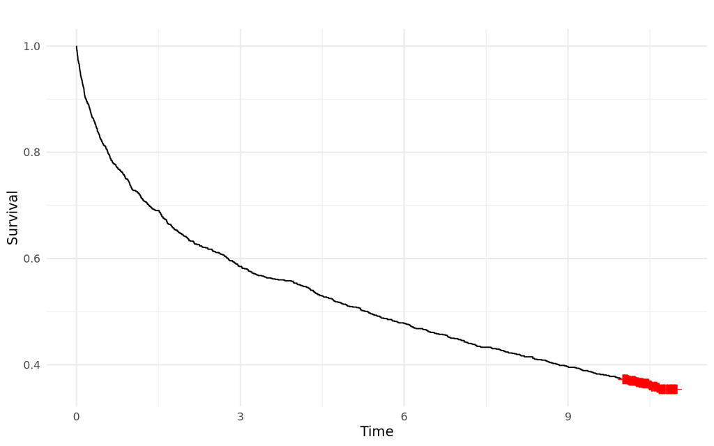

```r
library(GGally)
# Explore Kaplan-Meier curve
mlr3viz::autoplot(surv_task)
```

## Build the learner (survival RF from ranger package)

```r
library(ranger)

#built learner
ranger_lrn <- mlr3::lrn(
  "surv.ranger",
  respect.unordered.factors = "order",
  verbose = FALSE,
  importance = "permutation"
) #Variable importance mode
# Inspect parameters

ranger_lrn$param_set
```

```
## <ParamSet(29)>
##                               id    class lower upper nlevels        default
##                           <char>   <char> <num> <num>   <num>         <list>
##  1:                        alpha ParamDbl  -Inf   Inf     Inf            0.5
##  2:       always.split.variables ParamUty    NA    NA     Inf <NoDefault[0]>
##  3:                      holdout ParamLgl    NA    NA       2          FALSE
##  4:                   importance ParamFct    NA    NA       4 <NoDefault[0]>
##  5:                   keep.inbag ParamLgl    NA    NA       2          FALSE
##  6:                    max.depth ParamInt     0   Inf     Inf         [NULL]
##  7:                min.node.size ParamInt     1   Inf     Inf              5
##  8:                      minprop ParamDbl  -Inf   Inf     Inf            0.1
##  9:                         mtry ParamInt     1   Inf     Inf <NoDefault[0]>
## 10:                   mtry.ratio ParamDbl     0     1     Inf <NoDefault[0]>
## 11:            num.random.splits ParamInt     1   Inf     Inf              1
## 12:                  num.threads ParamInt     1   Inf     Inf              1
```

[output cut: 50 more lines]

# Hyperparameter tuning

Now it’s time to tune!

We will tune the following parameters for random forest:

- number_of_trees: number of trees in the forest
- mtry: number of variables to possibly split at in each node.
- min_node_size: minimum number of observations in a terminal node

## Settings

### Set the parameter search space

The paradox package features highly configurable search spaces for any mlr3 learner. Below we will define first the search space.

```r
library(paradox)

search_space <- paradox::ps(
  num.trees = paradox::p_int(lower = 500, upper = 1000),
  mtry = paradox::p_int(
    lower = floor(length(surv_task$col_roles$feature) * 0.1),
    upper = floor(length(surv_task$col_roles$feature) * 0.9)
  ),
  min.node.size = paradox::p_int(lower = 2, upper = 40)
)
search_space
```

```
## <ParamSet(3)>
##               id    class lower upper nlevels        default  value
##           <char>   <char> <num> <num>   <num>         <list> <list>
## 1:     num.trees ParamInt   500  1000     501 <NoDefault[0]> [NULL]
## 2:          mtry ParamInt     1    11      11 <NoDefault[0]> [NULL]
## 3: min.node.size ParamInt     2    40      39 <NoDefault[0]> [NULL]
```

### Select resampling strategy and performance measure

We need to specify how to evaluate the performance of a trained model. For this, we need to choose a resampling strategy and a performance measure. Here we choose cross-validation and C-index.

```r
#choose strategy and measure ####
#3-fold cross validation
hout <- mlr3::rsmp("cv", folds = 3)
measure <- mlr3::msr("surv.cindex")
```

### Generate tuning instance

mlr3tuning is the hyperparameter optimization package of the mlr3 ecosystem.

```r
library(mlr3tuning)

#generate tuning instance, from task, learner, search space, resampling method and measure
instance <- mlr3tuning::TuningInstanceBatchSingleCrit$new(
  task = surv_task,
  learner = ranger_lrn,
  resampling = hout,
  measure = measure,
  search_space = search_space,
  terminator = mlr3tuning::trm("none")
)
```

## Define grid search

```r
#The resolution is the number of distinct values to try per hyperparameter,
#which means in our example the tuner will construct a 2x2x2 grid of 8 configurations
#of equally spaced points between the specified upper and lower bounds
tuner <- mlr3tuning::tnr("grid_search", resolution = 2)
```

## Initiate tuning

We use parallelization for training purposes

```r
#packages needed for parallelization
library(doFuture)
library(doRNG)
library(foreach)
tictoc::tic()
# enable parallel processing
doFuture::registerDoFuture()
future::plan(future::multisession, workers =  availableCores() - 1)

# specify seed
doRNG::registerDoRNG(seed = 123)


tuner$optimize(instance)
```

```
## INFO  [16:01:35.875] [bbotk] Starting to optimize 3 parameter(s) with '<OptimizerBatchGridSearch>' and '<TerminatorNone>'
## INFO  [16:01:35.932] [bbotk] Evaluating 1 configuration(s)
## INFO  [16:01:36.007] [mlr3] Running benchmark with 3 resampling iterations
## INFO  [16:01:40.532] [mlr3] Applying learner 'surv.ranger' on task 'surv_example' (iter 1/3)
## INFO  [16:01:58.101] [mlr3] Applying learner 'surv.ranger' on task 'surv_example' (iter 2/3)
## INFO  [16:02:17.921] [mlr3] Applying learner 'surv.ranger' on task 'surv_example' (iter 3/3)
## INFO  [16:04:25.678] [mlr3] Finished benchmark
## INFO  [16:04:25.960] [bbotk] Result of batch 1:
## INFO  [16:04:25.963] [bbotk]  num.trees mtry min.node.size surv.cindex warnings errors runtime_learners
## INFO  [16:04:25.963] [bbotk]       1000   11            40   0.7579412        0      0          378.408
## INFO  [16:04:25.963] [bbotk]                                 uhash
## INFO  [16:04:25.963] [bbotk]  76745f48-eda3-4cc6-974b-0310afad6899
## INFO  [16:04:25.967] [bbotk] Evaluating 1 configuration(s)
## INFO  [16:04:25.978] [mlr3] Running benchmark with 3 resampling iterations
## INFO  [16:04:30.805] [mlr3] Applying learner 'surv.ranger' on task 'surv_example' (iter 1/3)
## INFO  [16:04:41.444] [mlr3] Applying learner 'surv.ranger' on task 'surv_example' (iter 2/3)
## INFO  [16:04:57.550] [mlr3] Applying learner 'surv.ranger' on task 'surv_example' (iter 3/3)
## INFO  [16:05:34.044] [mlr3] Finished benchmark
## INFO  [16:05:34.089] [bbotk] Result of batch 2:
## INFO  [16:05:34.092] [bbotk]  num.trees mtry min.node.size surv.cindex warnings errors runtime_learners
## INFO  [16:05:34.092] [bbotk]       1000    1             2    0.701391        0      0           107.31
## INFO  [16:05:34.092] [bbotk]                                 uhash
## INFO  [16:05:34.092] [bbotk]  7659d1b1-32f1-449a-8271-0d48d16d4efa
## INFO  [16:05:34.096] [bbotk] Evaluating 1 configuration(s)
## INFO  [16:05:34.107] [mlr3] Running benchmark with 3 resampling iterations
## INFO  [16:05:38.828] [mlr3] Applying learner 'surv.ranger' on task 'surv_example' (iter 1/3)
## INFO  [16:05:52.252] [mlr3] Applying learner 'surv.ranger' on task 'surv_example' (iter 2/3)
## INFO  [16:06:11.142] [mlr3] Applying learner 'surv.ranger' on task 'surv_example' (iter 3/3)
## INFO  [16:07:20.986] [mlr3] Finished benchmark
## INFO  [16:07:21.032] [bbotk] Result of batch 3:
## INFO  [16:07:21.035] [bbotk]  num.trees mtry min.node.size surv.cindex warnings errors runtime_learners
## INFO  [16:07:21.035] [bbotk]        500   11             2   0.7540331        0      0          206.613
## INFO  [16:07:21.035] [bbotk]                                 uhash
## INFO  [16:07:21.035] [bbotk]  e44d6e22-b15c-43a5-8e28-7781ed1130b9
## INFO  [16:07:21.038] [bbotk] Evaluating 1 configuration(s)
## INFO  [16:07:21.049] [mlr3] Running benchmark with 3 resampling iterations
## INFO  [16:07:26.128] [mlr3] Applying learner 'surv.ranger' on task 'surv_example' (iter 1/3)
## INFO  [16:07:42.231] [mlr3] Applying learner 'surv.ranger' on task 'surv_example' (iter 2/3)
## INFO  [16:08:02.883] [mlr3] Applying learner 'surv.ranger' on task 'surv_example' (iter 3/3)
## INFO  [16:08:32.490] [mlr3] Finished benchmark
```

[output cut: 39 more lines]

```
## INFO  [16:13:45.782] [mlr3] Running benchmark with 3 resampling iterations
## INFO  [16:13:49.717] [mlr3] Applying learner 'surv.ranger' on task 'surv_example' (iter 1/3)
## INFO  [16:14:00.331] [mlr3] Applying learner 'surv.ranger' on task 'surv_example' (iter 2/3)
## INFO  [16:14:13.531] [mlr3] Applying learner 'surv.ranger' on task 'surv_example' (iter 3/3)
## INFO  [16:14:29.424] [mlr3] Finished benchmark
## INFO  [16:14:29.471] [bbotk] Result of batch 8:
## INFO  [16:14:29.474] [bbotk]  num.trees mtry min.node.size surv.cindex warnings errors runtime_learners
## INFO  [16:14:29.474] [bbotk]        500    1            40   0.6946753        0      0           47.389
## INFO  [16:14:29.474] [bbotk]                                 uhash
## INFO  [16:14:29.474] [bbotk]  e7927809-720f-49b8-bc59-50a46674c719
## INFO  [16:14:29.494] [bbotk] Finished optimizing after 8 evaluation(s)
## INFO  [16:14:29.495] [bbotk] Result:
## INFO  [16:14:29.498] [bbotk]  num.trees  mtry min.node.size learner_param_vals  x_domain surv.cindex
## INFO  [16:14:29.498] [bbotk]      <int> <int>         <int>             <list>    <list>       <num>
## INFO  [16:14:29.498] [bbotk]        500    11            40          <list[7]> <list[3]>    0.758176
```

```
##    num.trees  mtry min.node.size learner_param_vals  x_domain surv.cindex
##        <int> <int>         <int>             <list>    <list>       <num>
## 1:       500    11            40          <list[7]> <list[3]>    0.758176
```

```r
# disable parallel backend
foreach::registerDoSEQ()

tictoc::toc()
```

```
## 806.051 sec elapsed
```

```r
#Uncomment next line to save the tuning
qs::qsave(instance, here::here("ML", "htune_demo.qs"))
```

## Evaluate tuning performance

How did all the possible parameter combinations do?

```r
#Uncomment next line to open the tuning
#instance <- qs::qread(here::here("ML", "htune_demo.qs"))
hyparams <- instance$search_space$ids()
perf_data <- instance$archive$data

perf_data %>%
  dplyr::select(num.trees, mtry,    min.node.size,  surv.cindex) %>%
  arrange(desc(surv.cindex)) %>%
  mutate(surv.cindex = surv.cindex %>% round(., digits = 4)) %>%
  kableExtra::kable(escape = FALSE) %>%
  kableExtra::kable_styling(
    bootstrap_options = "striped",
    full_width = FALSE,
    position = "left"
  ) %>%
  kableExtra::column_spec(1, bold = TRUE) %>%
  kableExtra::row_spec(0,
                       bold = TRUE,
                       background = "#666666",
                       color = "white")
```

| num.trees | mtry | min.node.size | surv.cindex |
| --- | --- | --- | --- |
| 500 | 11 | 40 | 0.7582 |
| 1000 | 11 | 40 | 0.7579 |
| 1000 | 11 | 2 | 0.7550 |
| 500 | 11 | 2 | 0.7540 |
| 500 | 1 | 2 | 0.7019 |
| 1000 | 1 | 2 | 0.7014 |
| 1000 | 1 | 40 | 0.6951 |
| 500 | 1 | 40 | 0.6947 |

# Final model training and performance evaluation

## Train the final learner

Select the best hyperparameters based on the best performance model, and include them into the ranger learner.

```r
# adding best hyperparameters
ranger_lrn$param_set$values <- c(
  ranger_lrn$param_set$values,
  perf_data %>%
    select(num.trees, mtry, min.node.size,  surv.cindex) %>%
    arrange(desc(surv.cindex)) %>%
    select(-surv.cindex) %>%
    slice(1)
)
```

Train the final learner

```r
set.seed(1234)
final_rf <- ranger_lrn$train(task = surv_task)
```

## Cheking performance

Testing (unseen data - generalization performance)

```r
# predict the outcome with the test data
pred_test <- final_rf$predict_newdata(newdata = prep_data_test)
# Define the performance metrics
pred_measures <- suppressWarnings(mlr3::msrs("surv.cindex"))
# Estimate performance
test_performance <- pred_test$score(
  measures = pred_measures,
  task = surv_task,
  learner = final_rf,
  train_set = surv_task$row_ids
) %>%
  tibble::enframe(name = ".metric", value = ".estimate")
#print performance
test_performance %>%
  kableExtra::kable(escape = FALSE) %>%
  kableExtra::kable_styling(
    bootstrap_options = "striped",
    full_width = FALSE,
    position = "left"
  ) %>%
  kableExtra::column_spec(1, bold = TRUE) %>%
  kableExtra::row_spec(0,
                       bold = TRUE,
                       background = "#666666",
                       color = "white")
```

| .metric | .estimate |
| --- | --- |
| surv.cindex | 0.7552367 |

Training (just for ckecking purposes but we don’t rely on this)

```r
# predict the outcome with the test data
pred_train <- final_rf$predict_newdata(newdata = prep_data_train)

# Estimate performance
train_performance <- pred_train$score(
  measures = pred_measures,
  task = surv_task,
  learner = final_rf,
  train_set = surv_task$row_ids
) %>%
  tibble::enframe(name = ".metric", value = ".estimate")
# Print performance
train_performance %>%
  kableExtra::kable(escape = FALSE) %>%
  kableExtra::kable_styling(
    bootstrap_options = "striped",
    full_width = FALSE,
    position = "left"
  ) %>%
  kableExtra::column_spec(1, bold = TRUE) %>%
  kableExtra::row_spec(0,
                       bold = TRUE,
                       background = "#666666",
                       color = "white")
```

| .metric | .estimate |
| --- | --- |
| surv.cindex | 0.8606085 |

# Explainable AI

Explainable AI (xAI) refers to methods and techniques in artificial intelligence that make the decision-making processes of AI systems transparent and understandable to humans. It aims to provide insights into how models arrive at their predictions or decisions, thereby enhancing trust and accountability in AI applications. By using various interpretability techniques, xAI helps users comprehend the underlying factors influencing model outputs, facilitating better decision-making and addressing ethical concerns.

For more details, check the reference by Christoph Molnar.

Here we will explore two different techniques, permutation variable importance and partial dependence plots, which are model agnostic and look at the global interpretability of the model.

## Variable Feature Importance (VIMP)

Lastly, let’s learn about feature importance for this model. For a ranger model, we do need to add in the engine importance = “permutation”, in order to compute feature importance.

Permutation variable importance is a technique used to evaluate the significance of individual features in a predictive model by measuring the change in model performance when the values of a specific feature are randomly shuffled. This method helps identify which variables have the most substantial impact on the model’s predictions, providing insights into feature relevance (higher values indicate more importance).

```r
importance <- final_rf$importance() %>%
  as_tibble_col() %>%
  bind_cols(variables = final_rf$importance() %>% names()) %>%
  relocate(variables)

importance %>%
  DT::datatable(
    rownames = TRUE,
    filter = "top",
    selection = "single",
    extensions = c("Buttons"),
    options = list(
      lengthMenu = c(5, 10, 25, 50),
      pageLength = 5,
      scrollX = TRUE,
      dom = "lfrtBpi",
      buttons = list("excel")
    )
  )
```

|  | variables | value |
| --- | --- | --- |
| 1 | .trt | 0.139672420674656 |
| 2 | bm05 | 0.1016596714218944 |
| 3 | bm02 | 0.0652200897423471 |
| 4 | bm04 | 0.01746342623055425 |
| 5 | bm14 | 0.00071379957684531 |
| 6 | bm18 | 7.640580244019324e-05 |
| 7 | bm07 | -5.719737701135563e-05 |
| 8 | bm09 | -0.0001335270957004768 |
| 9 | bm08 | -0.0001855916135752611 |
| 10 | bm12 | -0.0004580536191102911 |

[output cut: 3 more lines]

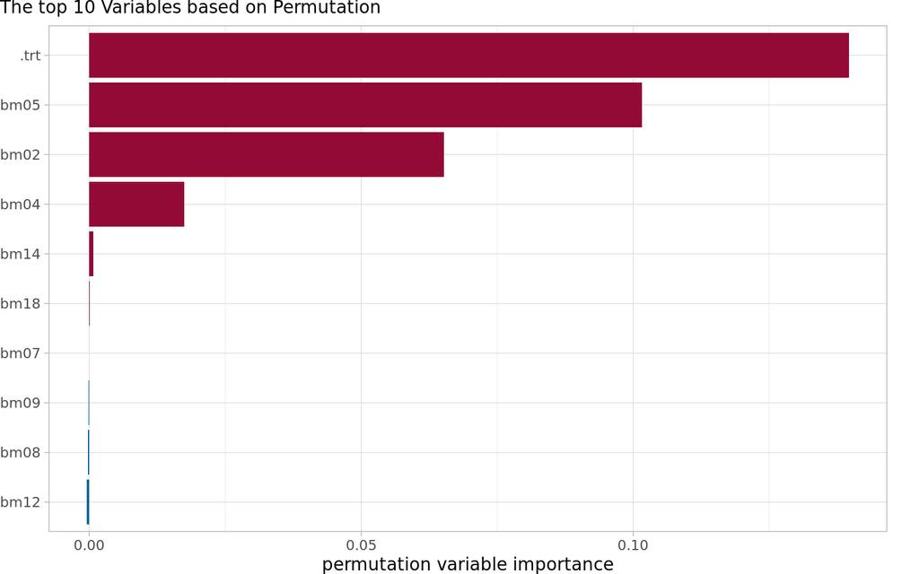

```r
# top 10
vi_nplot <- 10

#plot permutation importance
imp_fr_plt <- importance %>%
  dplyr::arrange(., desc(value)) %>%
  dplyr::slice(1:vi_nplot) %>%
  dplyr::mutate(Sign = as.factor(ifelse(value > 0, "positive", "negative")))

p <- imp_fr_plt %>%
  ggplot(aes(
    y = reorder(variables, value),
    x = value,
    fill = Sign
  )) +
  geom_col() +
  scale_fill_manual(values = c("#00659C", "#930A34")) +
  theme(
    legend.position = "none",
    axis.title.y = element_blank(),
    plot.subtitle = element_text(size = 11),
    plot.title.position = "plot",
    plot.margin = margin(r = 20)
  ) +
  labs(subtitle = paste0("The top ", vi_nplot, " Variables based on Permutation"))+
  xlab("permutation variable importance")


#plot output
p
```

## Partial dependency plots (PDPs)

We will use all available data: train + test

Partial dependence plots (PDPs) are graphical representations that illustrate the relationship between a specific feature and the predicted outcome of a model while averaging out the effects of other features. They help visualize how changes in the selected feature influence the model’s predictions.

```r
library(tidyverse)
library(ranger)
rf_model <- final_rf$model
# define time points represented by rank/order they appear
time_points <-
  seq(
    from = 1,
    to = length(rf_model$unique.death.times),
    length.out = 10
  ) %>% round()
```

Note: PDP predictions chunk set to eval=FALSE If one wants to run this chunk needs to set eval=TRUE. If one wants to save the outcome needs to uncoment the relevant line(see comments in the code)

### .trt

Calculate PDPs

```r
# define feature and grid (based on feature class)
feat <- ".trt"

feat_cat <- data_prep %>% dplyr::pull(!!feat) %>% class()
n_grid <- 50


if (feat_cat == "numeric") {
  feat_range <- data_prep %>%
    dplyr::pull(!!feat) %>%
    range()

  feat_grid <-
    seq(from = feat_range[1],
        to = feat_range[2],
        length.out = n_grid)

} else {
  feat_grid <- data_prep %>%
    dplyr::pull(!!feat) %>%
    levels()
}

# replace corresponding feature values with grid values
data_sets <-  purrr::map(feat_grid,
                         ~ data_prep %>% dplyr::mutate(dplyr::across(
                           tidyselect::all_of(feat),
                           .fns = function(y)
                             .x
                         )))

# calculate predictions for specified time points
preds <- map(
  data_sets,
  ~ ranger:::predict.ranger(rf_model, data = .x)$survival %>%
    tibble::as_tibble() %>%
    dplyr::select(all_of(time_points))
)
# calculate PDPs (average (survival probability) for each feature grid value per timepoint)
pdp_data <- purrr::map2(
  preds,
  feat_grid,
  ~ .x %>%
    apply(2, mean) %>%
    tibble::enframe(value = ".value", name = "time_id") %>%
    dplyr::mutate(time_id = stringr::str_replace(time_id, "V", "") %>% as.numeric()) %>%
    dplyr::mutate(feat_val1 = .y)
) %>%
  dplyr::bind_rows() %>%
  dplyr::rename({
    {
      feat
    }
  } := feat_val1)
```

Plot PDPs

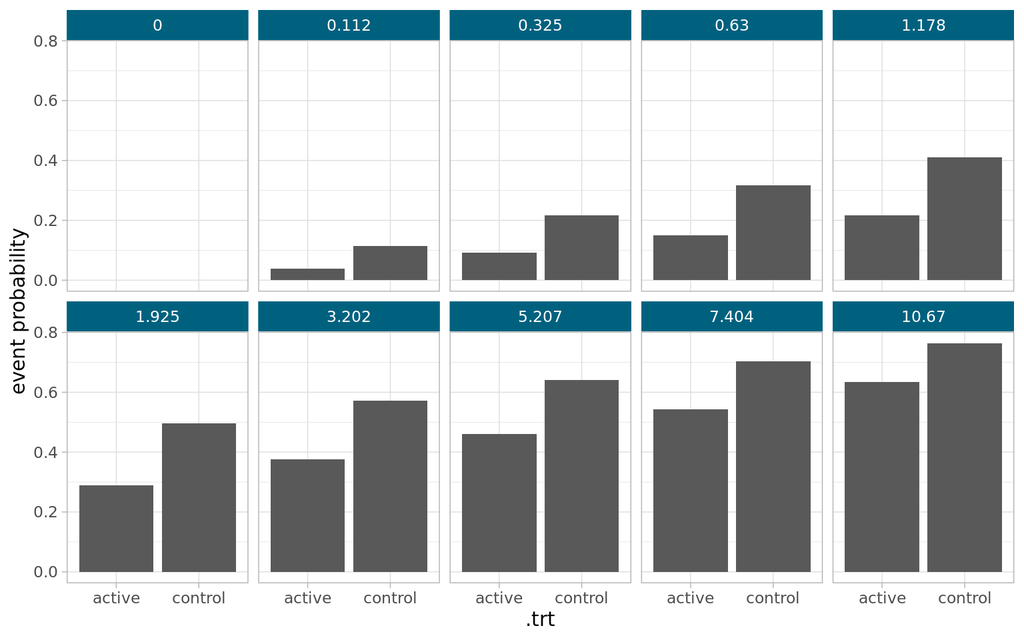

```r
p<-pdp_data %>%
  ggplot(aes(x = !!rlang::sym(feat), y = 1 - .value)) + # 1 minus for event probability, not survival prob
  { if (feat_cat == "numeric") geom_line() else geom_col()} +
  facet_wrap(~ time_id,
             nrow = 2,
             labeller =  ggplot2::labeller(time_id  = function(s) {rf_model$unique.death.times[as.numeric(s)] %>% round(3) }, # construct time labels within the function
                                           .default = ggplot2::label_value)) +
  ylab("event probability")
p
```

### bm02

```r
# define feature and grid (based onf feature class)
feat <- "bm02"

feat_cat <- data_prep %>% dplyr::pull(!!feat) %>% class()
n_grid <- 10


if (feat_cat == "numeric") {
  feat_range <- data_prep %>%
    dplyr::pull(!!feat) %>%
    range()

  feat_grid <-
    seq(from = feat_range[1],
        to = feat_range[2],
        length.out = n_grid)

} else {
  feat_grid <- data_prep %>%
    dplyr::pull(!!feat) %>%
    levels()
}

# replace corresponding feature values with grid values
data_sets <-  purrr::map(feat_grid,
                         ~ data_prep %>% dplyr::mutate(dplyr::across(
                           tidyselect::all_of(feat),
                           .fns = function(y)
                             .x
                         )))


# calculate predictions for specified time points ####
preds <- map(
  data_sets,
  ~ ranger:::predict.ranger(rf_model, data = .x)$survival %>%
    tibble::as_tibble() %>%
    dplyr::select(all_of(time_points))
)
# calculate PDPs (average (survival probability) for each feature grid value per timepoint)
pdp_data <- purrr::map2(
  preds,
  feat_grid,
  ~ .x %>%
    apply(2, mean) %>%
    tibble::enframe(value = ".value", name = "time_id") %>%
    dplyr::mutate(time_id = stringr::str_replace(time_id, "V", "") %>% as.numeric()) %>%
    dplyr::mutate(feat_val1 = .y)
) %>%
  dplyr::bind_rows() %>%
  dplyr::rename({
    {
      feat
    }
  } := feat_val1)
```

Plot PDPs

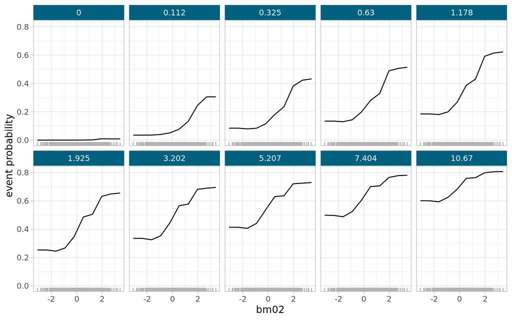

```r
feat <- "bm02"
feat_cat <- data_prep %>% dplyr::pull(!!feat) %>% class()

#create rug for bm02
feat_rug <- data_prep %>%
  dplyr::pull(!!feat)
#plot
p <- pdp_data %>%
  ggplot(aes(x = !!rlang::sym(feat), y = 1 - .value)) + # 1 minus for event probability, not survival prob
  {
    if (feat_cat == "numeric")
      geom_line()
    else
      geom_col()
  } +
  facet_wrap(
    ~ time_id,
    nrow = 2,
    labeller =  ggplot2::labeller(
      time_id  = function(s) {
        rf_model$unique.death.times[as.numeric(s)] %>% round(3)
      },
      # construct time labels within the function
      .default = ggplot2::label_value
    )
  ) +
  ylab("event probability")

p + ggplot2::geom_rug(
  data = feat_rug %>%
    tibble::enframe(),
  mapping = ggplot2::aes(x = value),
  inherit.aes = F,
  sides = "b",
  alpha = 1,
  col = "#B3B3B3"
)
```

### .trt and bm05, 2-d pdp

Calculate 2D PDPs for bm05 and.trt

2D partial dependence plots (PDPs) help visualize interactions between two features by displaying how the predicted outcomes change based on varying values of both features, allowing for a clearer understanding of their combined effects on the model’s predictions.

```r
# define grid ####
feat <- c("bm05", ".trt")

n_grid <- 10

#create range for bm05
bm05_range <- data_prep %>%
  dplyr::pull(bm05) %>%
  range()

bm05_grid <-
  seq(from = bm05_range[1],
      to = bm05_range[2],
      length.out = n_grid)

#get trt levels
trt_grid <- data_prep %>%
  dplyr::pull(.trt) %>%
  levels()


# replace corresponding feature values with grid values
data_sets <-
  tidyr::expand_grid(bm05 = bm05_grid, .trt = trt_grid, data_prep %>% select(-c(bm05, .trt)))

# calculate predictions for specified time points

preds <-
  ranger:::predict.ranger(rf_model, data = data_sets)$survival %>%
  tibble::as_tibble() %>%
  dplyr::select(all_of(time_points))
```

```
## Aggregating predictions.. Progress: 88%. Estimated remaining time: 4 seconds.
```

```r
#merge predictions with data set and calculate 2D PDPs (average (survival probability) for each feature combination value per timepoint)
pdp_data  <- data_sets %>% bind_cols(preds) %>%
  filter(bm05 %in% bm05_grid) %>%
  pivot_longer(
    c(colnames(preds)),
    names_to = "time_id",
    values_to = ".values"
  )  %>% mutate(time_id = stringr::str_replace(time_id, "V", "") %>% as.numeric()) %>%
  group_by(bm05, .trt, time_id) %>% summarise(.value = mean(.values))

#Uncomment next line to save the outcome
#qs::qsave(pdp_data, here::here("Data", "bm05_trt_int_pdp_preds.qs"))
```

Plot PDPs

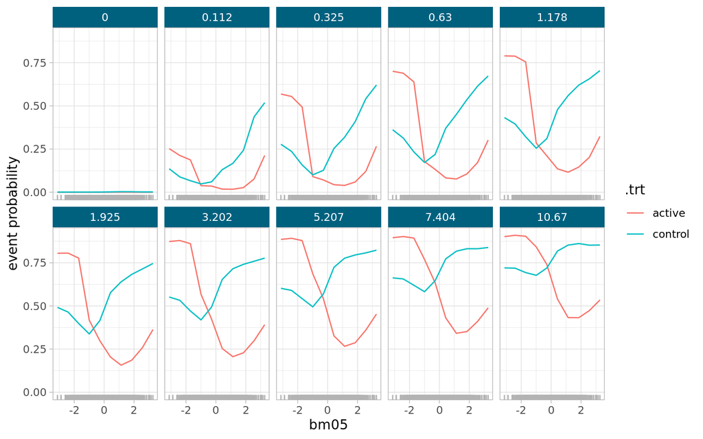

```r
#rug
bm05_rug <- data_prep %>%
  dplyr::pull(bm05)

#Uncomment next line to open the outcome
#pdp_data <- qs::qread(here::here("Data", "bm05_trt_int_pdp_preds.qs"))

#create range for bm05
bm05_range <- data_prep %>%
  dplyr::pull(bm05) %>%
  range()
#plot
p <- pdp_data %>%
  ggplot2::ggplot(aes(
    x = bm05,
    y = 1 - .value,
    color = .trt
  )) + # 1 minus for event probability, not survival prob
  geom_line()    +
  facet_wrap(
    ~ time_id,
    nrow = 2,
    labeller =  ggplot2::labeller(
      time_id  = function(s) {
        rf_model$unique.death.times[as.numeric(s)] %>% round(3)
      },
      # construct time labels within the function
      .default = ggplot2::label_value
    )
  ) +
  ylab("event probability")

p + ggplot2::geom_rug(
  data = bm05_rug %>% tibble::enframe(),
  mapping = ggplot2::aes(x = value),
  inherit.aes = F,
  sides = "b",
  alpha = 1,
  col = "#B3B3B3"
)
```

# References

- [mlr3](https://mlr3.mlr-org.com/)
- [Tidymodels](https://www.tidymodels.org/)
- [Interpretable Machine Learning](https://christophm.github.io/interpretable-ml-book/)
- [Explanatory Model Analysis](https://ema.drwhy.ai/)